# Reproducible Research Assignment 1

The purpose of this assignment is to write a report that answers the questions detailed below and complete the entire assignment in a single R markdown document that can be processed by knitr and be transformed into an HTML file.

# Data

This assignment makes use of data from a personal activity monitoring device. This device collects data at 5 minute intervals through out the day. The data consists of two months of data from an anonymous individual collected during the months of October and November, 2012 and include the number of steps taken in 5 minute intervals each day.

## Details

The data for this assignment can be downloaded from the course web site: *Dataset:* Activity monitoring data [52K] The variables included in this dataset are:

- steps: Number of steps taking in a 5-minute interval (missing values are coded as NA)
- date: The date on which the measurement was taken in YYYY-MM-DD format
- interval: Identifier for the 5-minute interval in which measurement was taken

The dataset is stored in a comma-separated-value (CSV) file and there are a total of 17,568 observations in this dataset.

# Processing

## Step 1: Load the data

1. Load the data (i.e. read.csv())
2. Process/transform the data (if necessary) into a format suitable for your analysis

```r
activity=read.csv("activity.csv")
activity$date <- as.Date(activity$date)
```

## Step 2: What is mean total number of steps taken per day?

1. Remove the missing values in the dataset.
2. Make a histogram of the total number of steps taken each day
3. Calculate and report the mean and median total number of steps taken per day

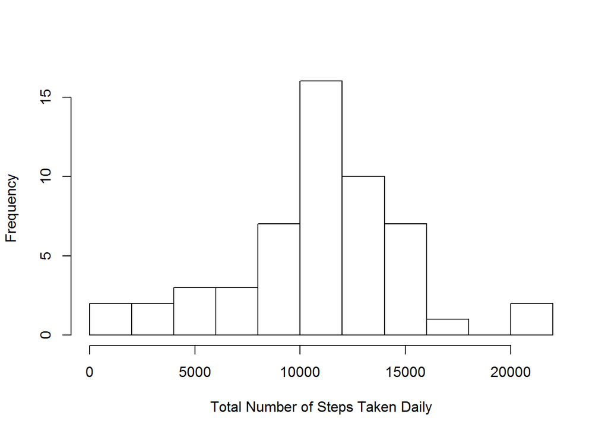

```r
activity2 <- na.omit(activity)

# Add steps by date
daily_steps <- rowsum(activity2$steps, format(activity2$date, '%Y-%m-%d'))
daily_steps <- data.frame(daily_steps)
names(daily_steps) <- ("steps")

# Make a histogram of the total number of steps taken each day
hist(daily_steps$steps,
     main=" ",
     breaks=10,
     xlab="Total Number of Steps Taken Daily")
```

```r
mean(daily_steps$steps)
```

[1] 10766.19

```r
median(daily_steps$steps)
```

[1] 10765

## Step 3: What is the average daily activity pattern?

1. Make a time series plot (i.e. type = “l”) of the 5-minute interval (x-axis) and the average number of steps taken, averaged across all days (y-axis)

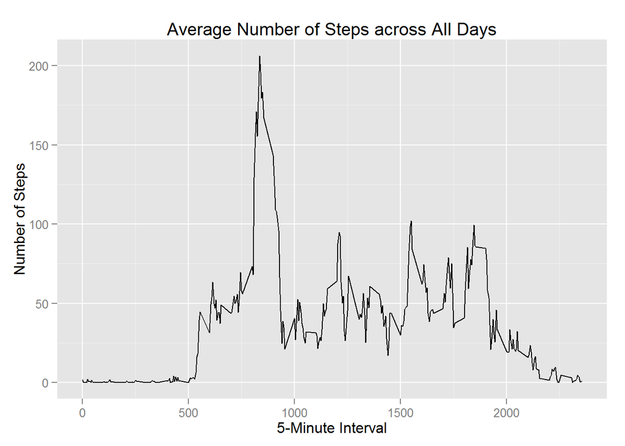

```r
library(plyr)
# Calculate average steps for each of 5-minute interval during a 24-hour period
interval_5min_steps <- ddply(activity2,~interval, summarise, mean=mean(steps))


library(ggplot2)
library(scales)
qplot(x=interval, y=mean, data = interval_5min_steps,  geom = "line",
      xlab="5-Minute Interval",
      ylab="Number of Steps",
      main="Average Number of Steps across All Days"
      )
```

```r
interval_5min_steps[which.max(interval_5min_steps$mean), ]
```

```
##     interval     mean
## 104      835 206.1698
```

Which 5-minute interval, on average across all the days in the dataset, contains the maximum number of steps?

Response: Interval 835 contains maximum number of steps.

## Step 4: Imputing missing values

There are a number of days/intervals where there are missing values (coded as NA). The presence of missing days may introduce bias into some calculations or summaries of the data.

1. Calculate and report the total number of missing values in the dataset (i.e. the total number of rows with NAs)

```r
r_missing = sum(is.na(activity$steps))
```

Observation: Total number of rows with NAs is 2304.

2. Devise a strategy for filling in all of the missing values in the dataset. The strategy does not need to be sophisticated. For example, you could use the mean/median for that day, or the mean for that 5-minute interval, etc.

```r
library(dplyr)
activity_complete <- activity %>% left_join(interval_5min_steps, by = "interval")

#Add a column for steps and fill it with mean whereer NA

activity_complete$newSteps <- ifelse(is.na(activity_complete$steps), activity_complete$mean, activity_complete$steps)
```

3. Create a new dataset that is equal to the original dataset but with the missing data filled in.

```r
# Drop the steps column as well as the mean column, and
# then rename the newSteps column as steps
activity_complete$steps <- NULL
activity_complete$mean <- NULL
colnames(activity_complete) <- c("date", "interval", "steps")

activity_complete <- activity_complete[, c(3, 1, 2)]
head(activity_complete)
```

```
##       steps       date interval
## 1 1.7169811 2012-10-01        0
## 2 0.3396226 2012-10-01        5
## 3 0.1320755 2012-10-01       10
## 4 0.1509434 2012-10-01       15
## 5 0.0754717 2012-10-01       20
## 6 2.0943396 2012-10-01       25
```

4. Make a histogram of the total number of steps taken each day and Calculate and report the mean and median total number of steps taken per day. Do these values differ from the estimates from the first part of the assignment? What is the impact of imputing missing data on the estimates of the total daily number of steps?

```
## stat_bin: binwidth defaulted to range/30. Use 'binwidth = x' to adjust this.
```

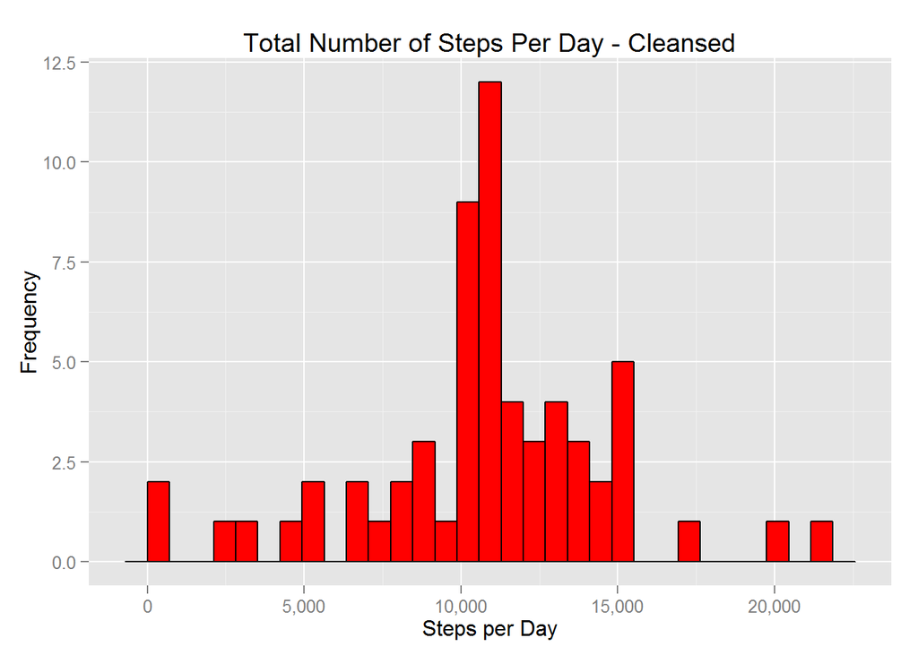

```r
library(dplyr)
steps_Day = activity_complete %>% group_by(date)%>% summarise(Steps=sum(steps))

Plot4 <- ggplot(data = steps_Day, mapping = aes(x = Steps)) + geom_histogram(fill = "red", colour = "black") + scale_x_continuous("Steps per Day", labels = comma) + scale_y_continuous("Frequency") + ggtitle("Total Number of Steps Per Day - Cleansed")
Plot4
```

Calculate and report the mean and median total number of steps taken per day.

```r
meanStepsPerDay <- mean(steps_Day$Steps, na.rm = TRUE)
meanStepsPerDay <- formatC(meanStepsPerDay, big.mark = ",", format = "f", digits = 0)
medStepsPerDay <- median(steps_Day$Steps, na.rm = TRUE)
mednStepsPerDay <- formatC(medStepsPerDay, big.mark = ",", format = "f", digits = 0)
```

Observation: Mean steps per day is 10,766 and median is 10,766 and the two values are same .

## Step 5: Are there differences in activity patterns between weekdays and weekends?

Use the dataset with the filled-in missing values for this part.

1. Create a new factor variable in the dataset with two levels - “weekday” and “weekend” indicating whether a given date is a weekday or weekend day.

```r
activity_complete$weekdayType <- ifelse(weekdays(activity_complete$date) %in% c("Satuday", "Sunday"),
    "weekend", "weekday")

head(activity_complete)
```

```
##       steps       date interval weekdayType
## 1 1.7169811 2012-10-01        0     weekday
## 2 0.3396226 2012-10-01        5     weekday
## 3 0.1320755 2012-10-01       10     weekday
## 4 0.1509434 2012-10-01       15     weekday
## 5 0.0754717 2012-10-01       20     weekday
## 6 2.0943396 2012-10-01       25     weekday
```

2. Make a panel plot containing a time series plot (i.e. type = “l”) of the 5-minute interval (x-axis) and the average number of steps taken, averaged across all weekday days or weekend days (y-axis).

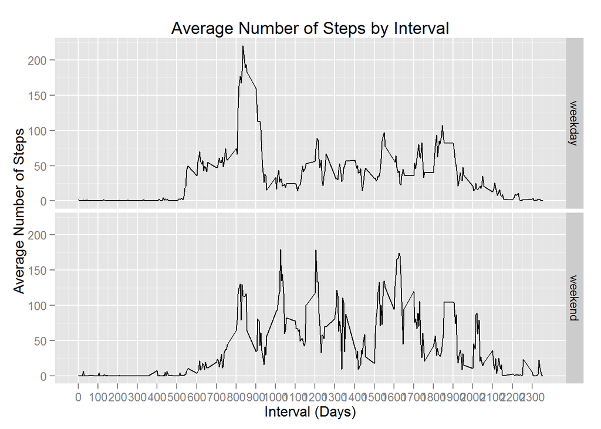

```r
act_compl_Interval2 <- activity_complete %>% group_by(interval, weekdayType) %>% summarise(meanSteps = mean(steps, na.rm = TRUE))

plot5 <- ggplot(data = act_compl_Interval2, mapping = aes(x = interval, y = meanSteps)) +  geom_line() + facet_grid(weekdayType ~ .) + scale_x_continuous("Interval (Days)", breaks = seq(min(act_compl_Interval2$interval), max(act_compl_Interval2$interval), 100)) + scale_y_continuous("Average Number of Steps") + ggtitle("Average Number of Steps by Interval")
plot5
```

Observation: Activity peaks occur at different time intervals across weekdays and weekends with people being more active during early part of weekday.